# Reproducible Research: Project 1

Load some useful libraries

```r
library(dplyr)
```

```r
library(ggplot2)
```

## Loading and preprocessing the data

1. Load the data

```r
activ <-read.csv("activity.csv", header = TRUE, colClasses = c("numeric","character","numeric"), na.strings = "NA")
```

2. Process/transform the data

```r
steps_per_day<-aggregate(steps~date,data=activ,FUN=sum )
```

## What is mean total number of steps per day?

1. Calculate the total number of steps taken per day

```r
head(steps_per_day)
```

```
##         date steps
## 1 2012-10-02   126
## 2 2012-10-03 11352
## 3 2012-10-04 12116
## 4 2012-10-05 13294
## 5 2012-10-06 15420
## 6 2012-10-07 11015
```

2. Histogram of the total number of steps taken per day

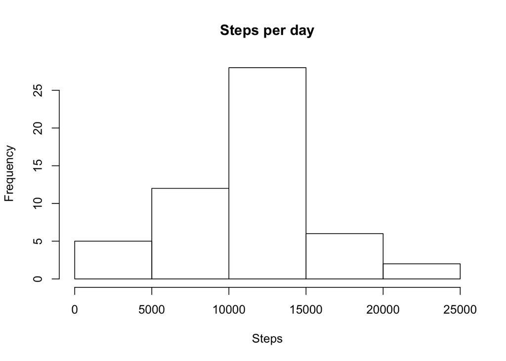

```r
hist(steps_per_day$steps,main="Steps per day",xlab = "Steps")
```

3. Mean and median of the total number of steps taken per day

```r
mean(steps_per_day$steps)
```

```
## [1] 10766.19
```

```r
median(steps_per_day$steps)
```

```
## [1] 10765
```

## What is the average daily activity patern?

1. Time series plot of the 5-minute interval (x-axis) and the average number of steps taken, averaged across all days (y-axis)

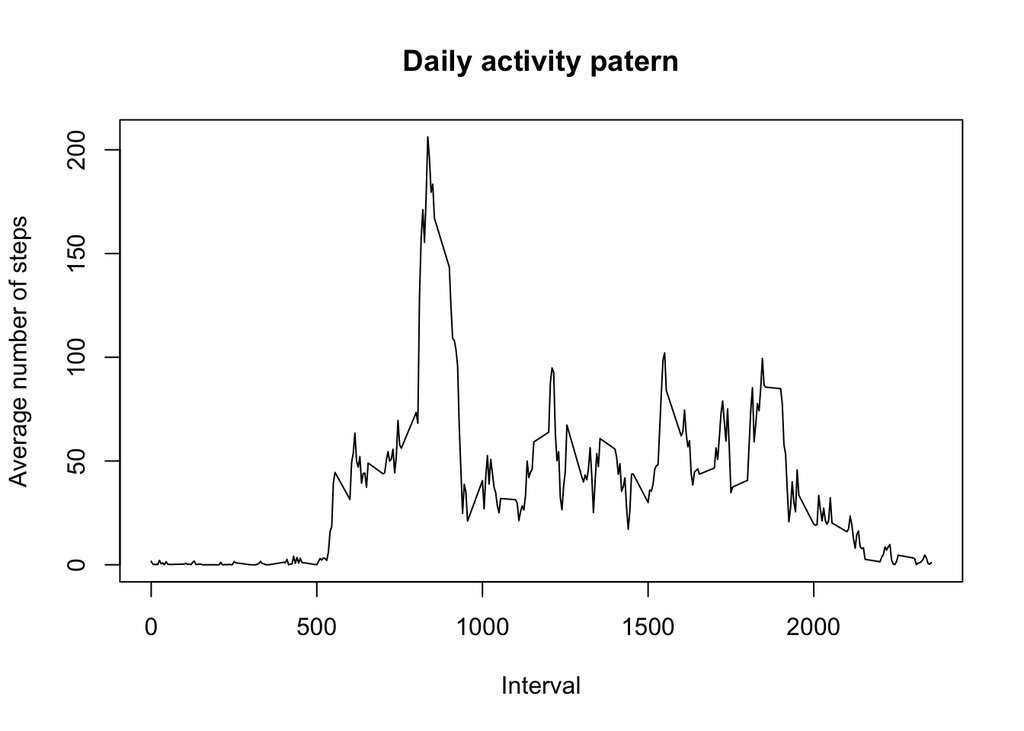

```r
steps_interval<-aggregate(steps~interval,data=activ,FUN=mean)
plot(steps_interval,type="l",main= "Daily activity patern", xlab="Interval",ylab="Average number of steps")
```

2. Interval with maximum number of steps.

```r
steps_interval[steps_interval$steps==max(steps_interval$steps),1]
```

```
## [1] 835
```

## Imputing missing values

1. Calculate and report the total number of missing values in the dataset

```r
nas<-!complete.cases(activ)
sum(nas)
```

```
## [1] 2304
```

2. Filling in the missing values in the dataset.

The estrategy is simple, replace the NA’s with the interval’s mean value for the corresponding interval doing the following,

- Match the NA values with the step per interval
- Generate a list of the mean values in the position of the NA’s
- Replace the NA’s with the mean values per interval
3. New dataset with the missing data filled in

```r
activ2<-activ
activ2[nas==TRUE,1]<-steps_interval[match(activ[nas==TRUE,3],steps_interval$interval),2]
head(activ2)
```

```
##       steps       date interval
## 1 1.7169811 2012-10-01        0
## 2 0.3396226 2012-10-01        5
## 3 0.1320755 2012-10-01       10
## 4 0.1509434 2012-10-01       15
## 5 0.0754717 2012-10-01       20
## 6 2.0943396 2012-10-01       25
```

4. Histogram of the total steps taken each day and the mean and median total number of steps taken per day.

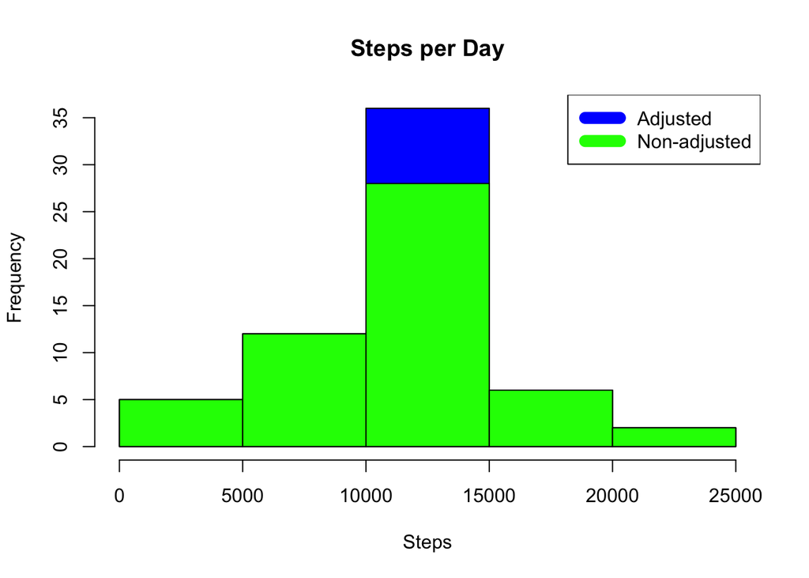

```r
steps_per_day2<-aggregate(steps~date,data=activ2,FUN=sum)
hist(steps_per_day2$steps,col="blue" ,main="Steps per Day",xlab = "Steps")
hist(steps_per_day$steps,col="green",add=T)
legend("topright",c("Adjusted", "Non-adjusted"),col=c("blue","green"),lwd=10)
```

Mean and median

```r
mean(steps_per_day2$steps)
```

```
## [1] 10766.19
```

```r
median(steps_per_day2$steps)
```

```
## [1] 10766.19
```

## Are there difference in activity patterns between weekdays and weekends?

1. Factor variable with two levels: weekday and weekend

```r
wdays<-c("Monday","Tuesday","Wednesday","Thursday","Friday")
wend<- c("Saturday","Sunday")
activ3<-activ
activ3$date<-factor(weekdays( as.Date(activ$date, "%Y-%m-%d") ) )
levels(activ3$date)<-list("Weekday"= wdays,"Weekend" = wend)
```

2. Panel plot of the time series of the 5-minute interval and the average number of steps taken (average across all weekdays or weekend days).

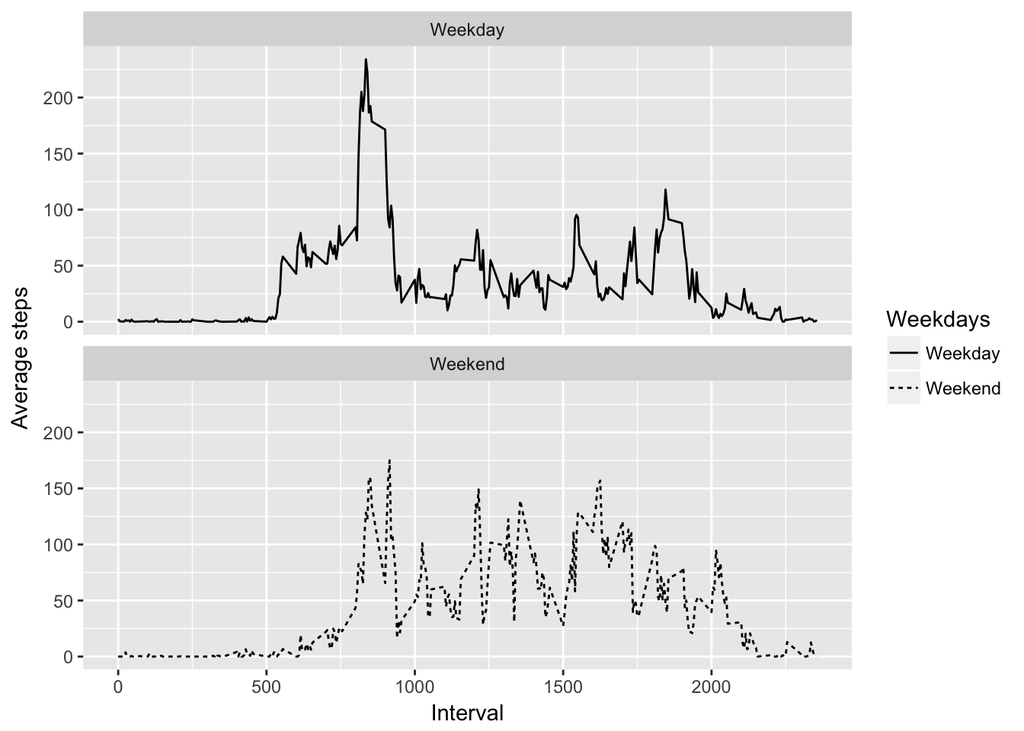

```r
aweekdays<-aggregate(steps~interval+date,activ3,mean)
plot<-ggplot(aweekdays,aes(x=interval,y=steps,linetype=date))+geom_line()+facet_wrap(~date,ncol=1,nrow=2)+xlab("Interval")+ylab("Average steps")+ labs(linetype = "Weekdays")
print(plot)
```